# Caña de azucar

Monroy Vargas Daniel

08/03/21

Naturaleza: La caña de azúcar es un tallo cilíndrico (de cinco a seis centímetros de diámetro), largado y leñoso el cual está lleno de un tejido esponjoso que acumula un jugo dulce rico en sacarosa (14% aproximadamente). Aparte de sacarosa, la caña de azúcar también contiene altos niveles de melaza. Una posible explicación para la evolución de la caña es que se originó a través de un proceso de selección de los tallos previamente cortados o podados más jugosos de la especie silvestre conocida como Saccharum robustum. La caña de azúcar llegó a España en el siglo IX, para que luego de seis siglos se expandiera por toda América.

Valor de uso: Este producto agropecuario ha tomado un papel demasiado importante a nivel mundial ya que aproximadamente el 70% de azúcar que se consume en todo el mundo depende de la caña de azúcar. También con la melaza que almacena su tallo, se fabrica el ron. Otros usos que se le pueden dar a la producción de caña de azúcar son la elaboración de etanol, fibras absorbentes, compost agrícola, ceras, entre otros.

Valor de cambio: México es de los principales productores de caña de azúcar en el mundo (la producción 2011 en toneladas fue de 49,735.300) Fuente: FAO 2011. pero a pesar de esto, el campesino nunca tiene garantizada su salud ni su vida ya que existen grandes riesgos en especial cuando hay que cosechar. La caña de azúcar representa el 0.4% del PIB y el 7.3% del PIB agropecuario. Aproximadamente hay 164,397 productores de caña de azúcar que se encuentran agremiados en tres agrupaciones: La Confederación Nacional de Propietarios Rurales (CNPR), Confederación Nacional Campesina (CNC), e independientes.

Valor: En nuestro país existen varias empresas azucareras, de las cuales cinco son las mas grandes e importantes de México, son: Beta San Miguel, Zucarmex, Grupo Paisa, Grupo Porres y Gam, todas ellas producen cerca de 2.5 millones de toneladas de azúcar de los 6 millones de toneladas que el país produce al año.

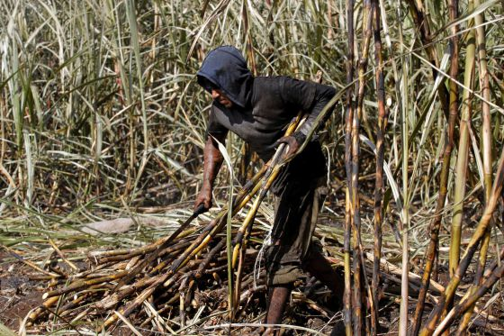

Fuente: El País

## Bibliografía

1. https://www.infoagro.com/documentos/el_cultivo_cana_azucar.asp
2. https://www.ecured.cu/Ca%C3%B1a_de_az%C3%BAcar
3. https://www.zafranet.com/productores-caneros/
4. https://panamericanworld.com/revista/economia/las-cinco-empresas-azucareras-mas-importantes-de-mexico/